Lake Name: Song Lake

Lake acreage: 105.4

County: CORTLAND

PWLID: 0602-0019

Waterbody Classification: B

Coordinates: 42.773444,-76.150615

Is this waterbody a public water supply: No

Are there DOH desingated beaches on this waterbody: Yes

Open Water Indicators

2018 Sampling Results

Seasonal Change

06-16

06-30

07-14

07-28

08-12

08-25

09-08

09-22

Clarity (m)

3.30

2.95

3.50

3.15

3.95

3.60

3.40

5.05

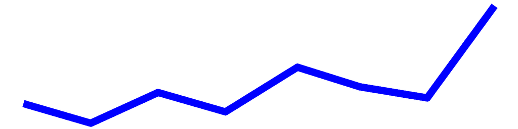

Surface TP (mg/L)

0.01

0.01

0.01

0.01

0.01

0.01

0.01

0.01

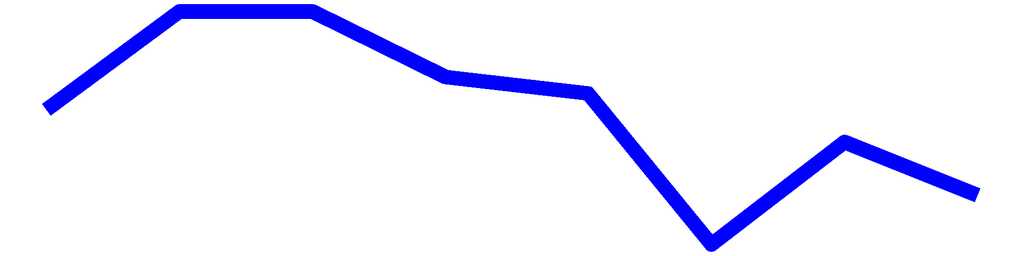

Surface TDP (mg/L)

0.01

0.01

0.01

0.01

0.00

0.01

0.00

0.01

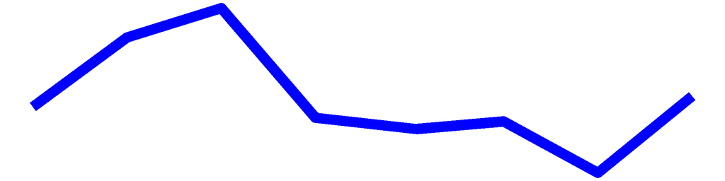

Deep TP (mg/L)

0.02

0.02

0.03

0.02

0.02

0.02

0.02

0.01

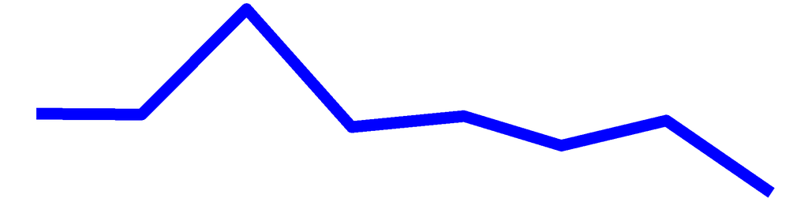

Deep TDP (mg/L)

0.01

0.01

0.01

0.02

0.01

0.01

0.00

0.00

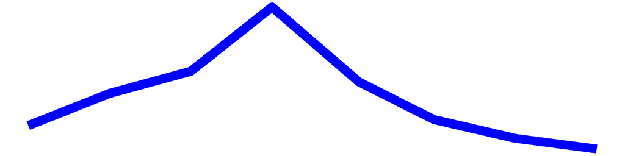

TN (mg/L)

0.53

0.55

0.39

0.55

0.43

0.46

0.33

0.43

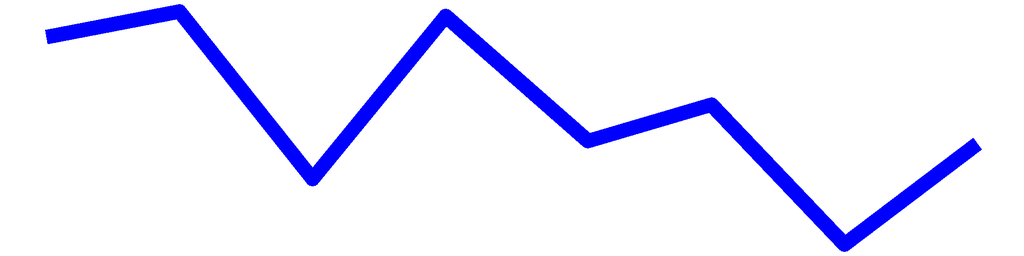

TDN (mg/L)

0.50

0.55

0.35

0.50

0.42

0.44

0.31

0.47

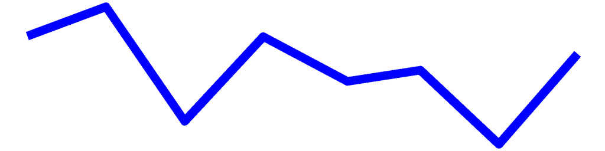

TN:TP

48.77

41.72

29.85

47.10

38.36

61.82

33.30

49.12

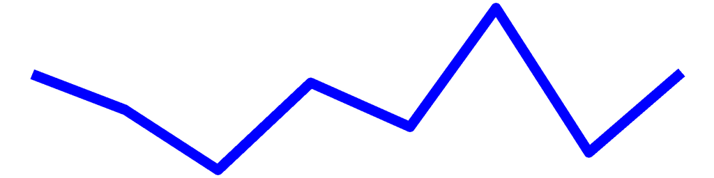

Surface NH3 (mg/L)

0.03

0.02

0.02

0.00

0.01

0.01

0.04

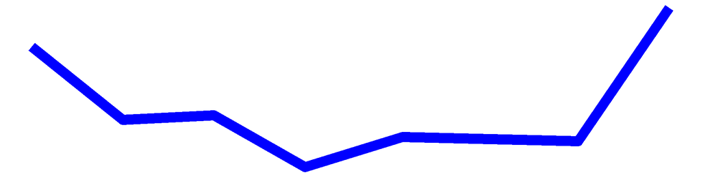

Deep NH3 (mg/L)

0.10

0.14

0.02

0.42

0.07

0.01

0.02

0.03

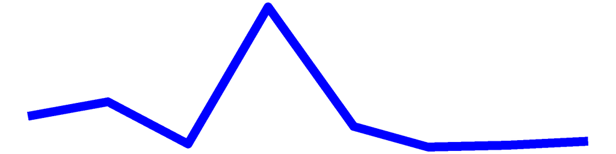

Chl.a (ug/L)

3.20

1.90

2.90

3.00

3.30

2.70

1.20

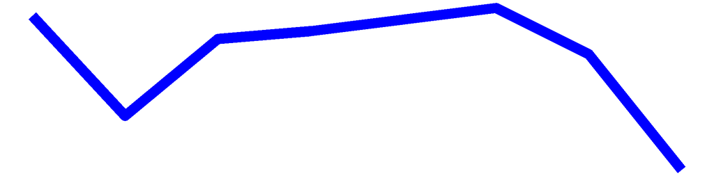

pH

8.08

8.59

7.94

7.87

7.21

7.42

7.72

7.18

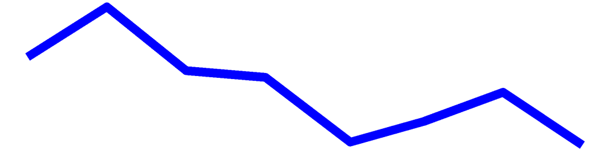

Cond (umho/cm)

199.20

233.80

198.40

208.80

203.20

120.10

137.90

187.90

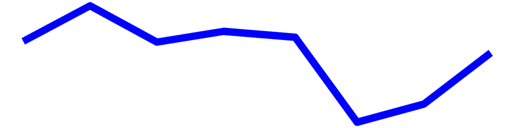

Surface Calcium (mg/L)

Bottom Calcium (mg/L)

Surface Chloride (mg/L)

18.00

13.70

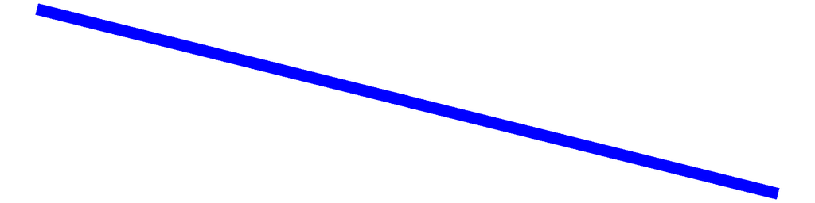

Bottom Chloride (mg/L)

Upper Temp (degC)

24.00

25.50

28.00

26.00

27.50

24.00

25.00

21.50

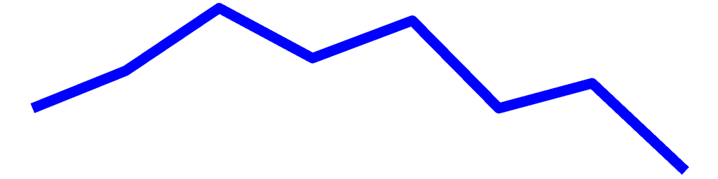

Deep Temp (degC)

22.00

21.00

23.50

25.50

27.00

23.50

22.70

21.50

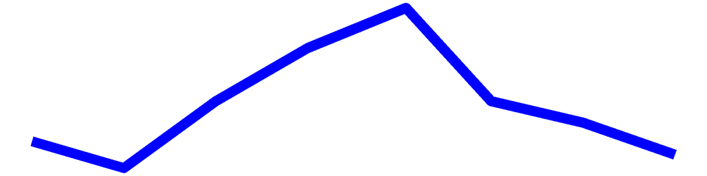

FP BG Chl.a (ug/L)

4.62

2.78

4.10

5.94

5.53

4.11

4.81

1.49

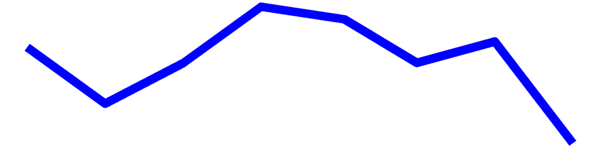

## Song Lake – Sampling Season Results

### HABs Status

#### Open Water Algae

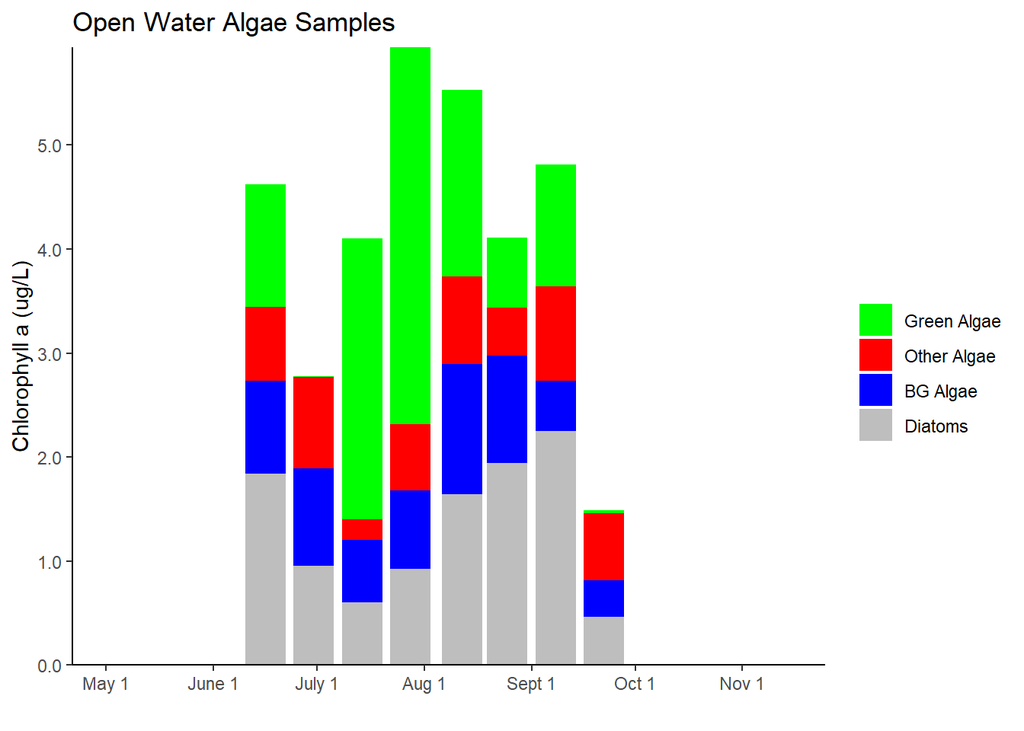

#### Shoreline Algae

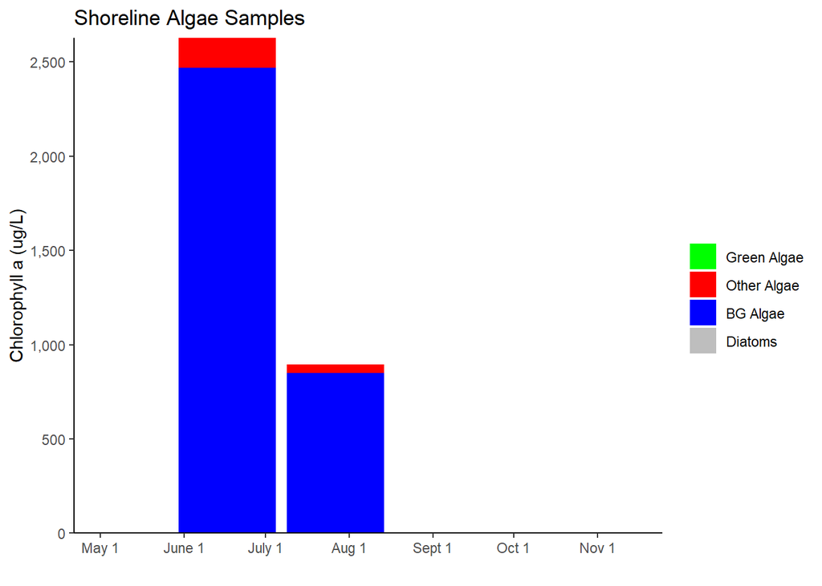

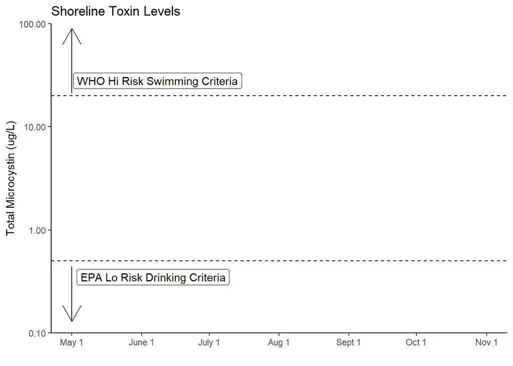

## Song Lake Long-Term Trend Analysis

#### Clarity

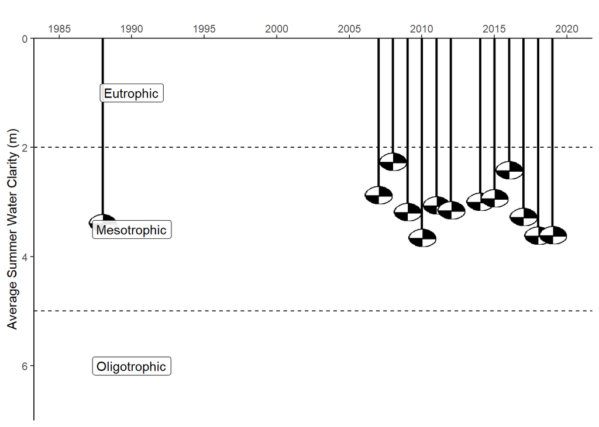

#### Chlorophyll *a*

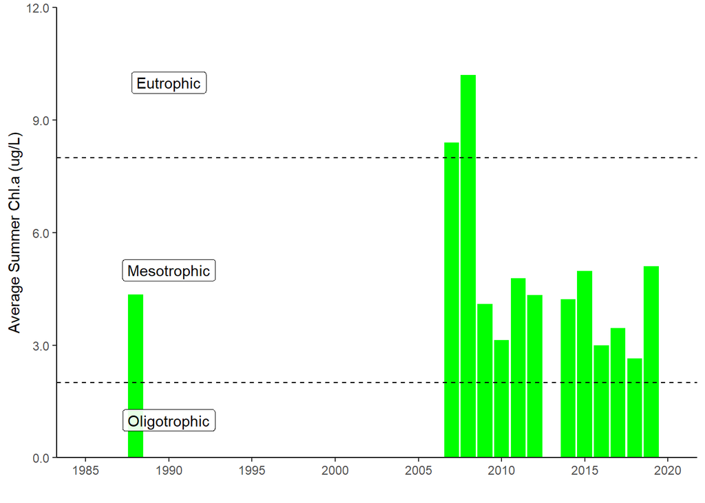

#### Surface and Deep Phosphorus

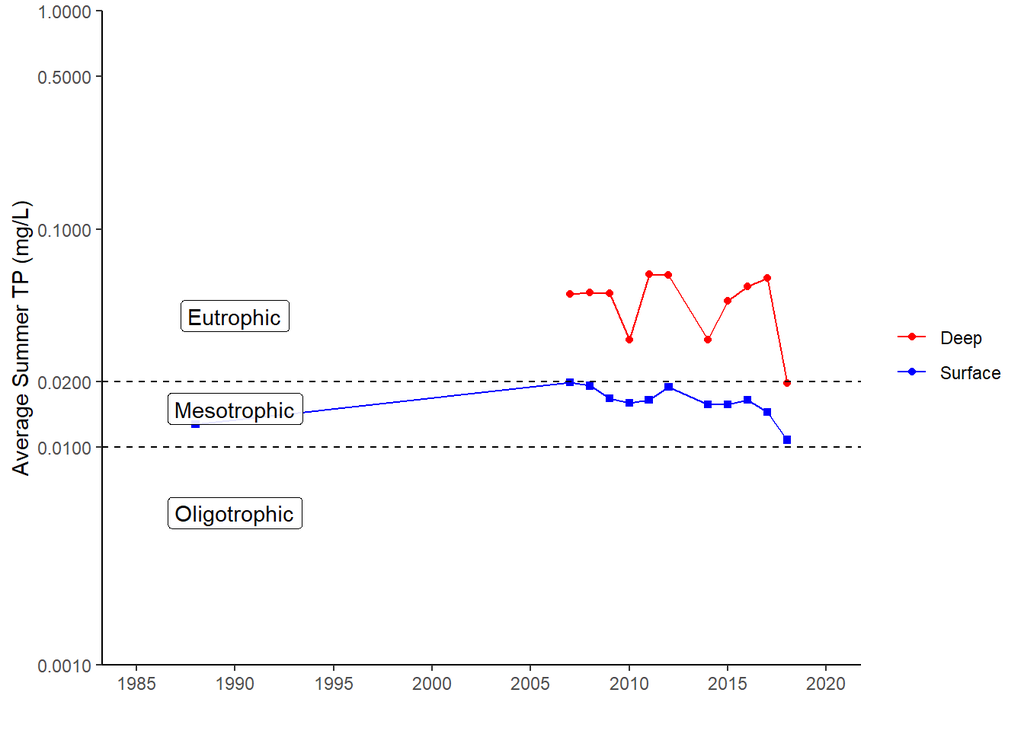

#### Nitrogen

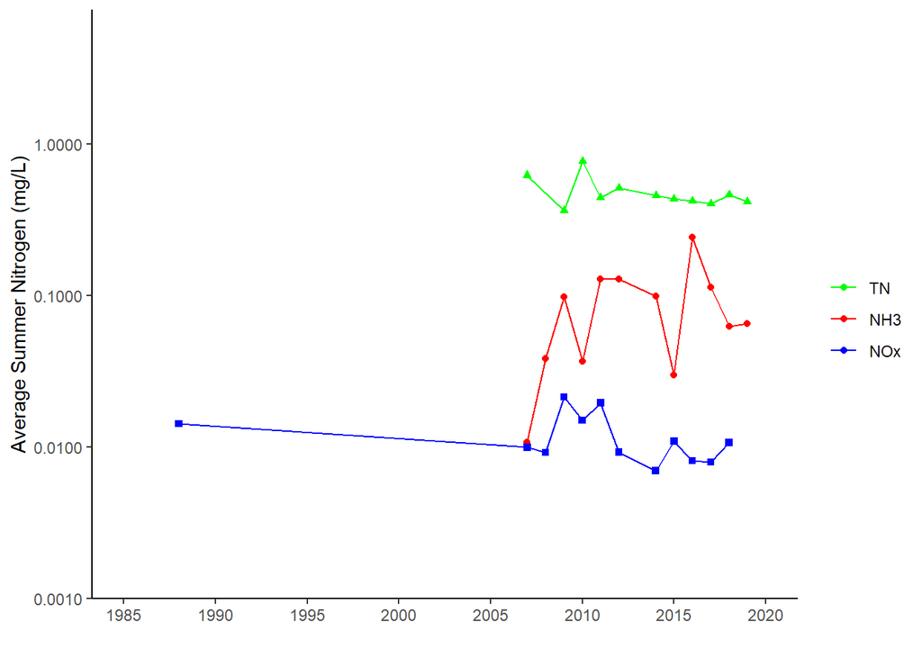

#### TN : TP

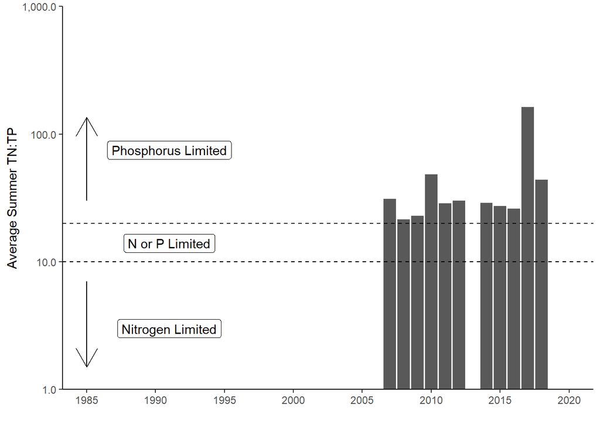

#### pH

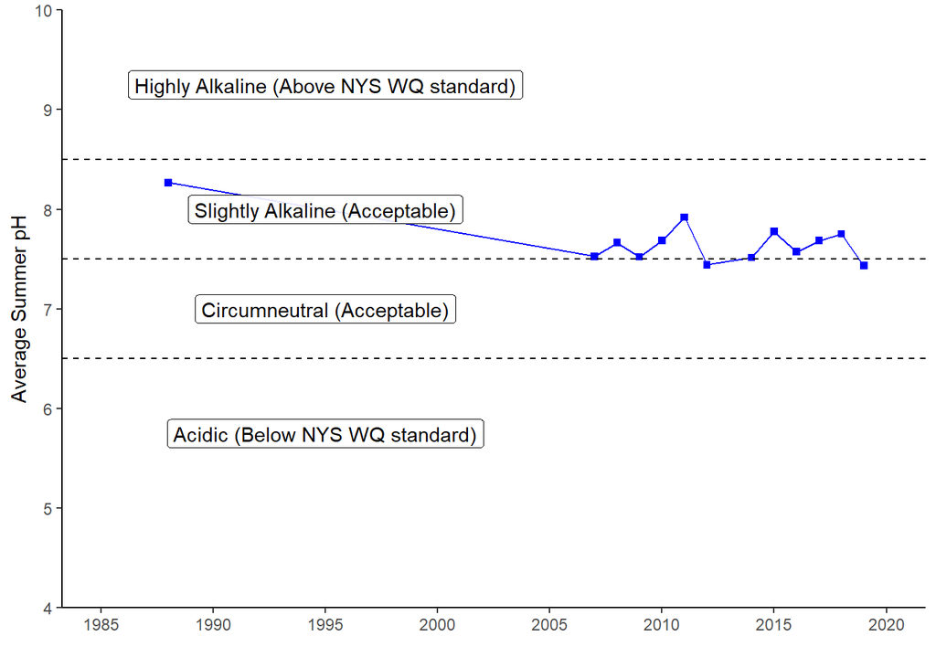

#### Specific Conductance

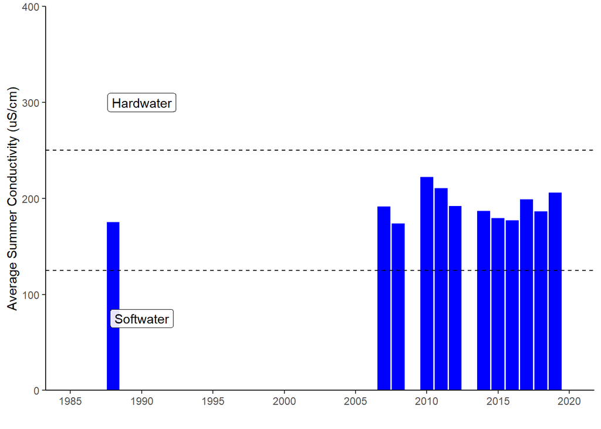

#### Calcium

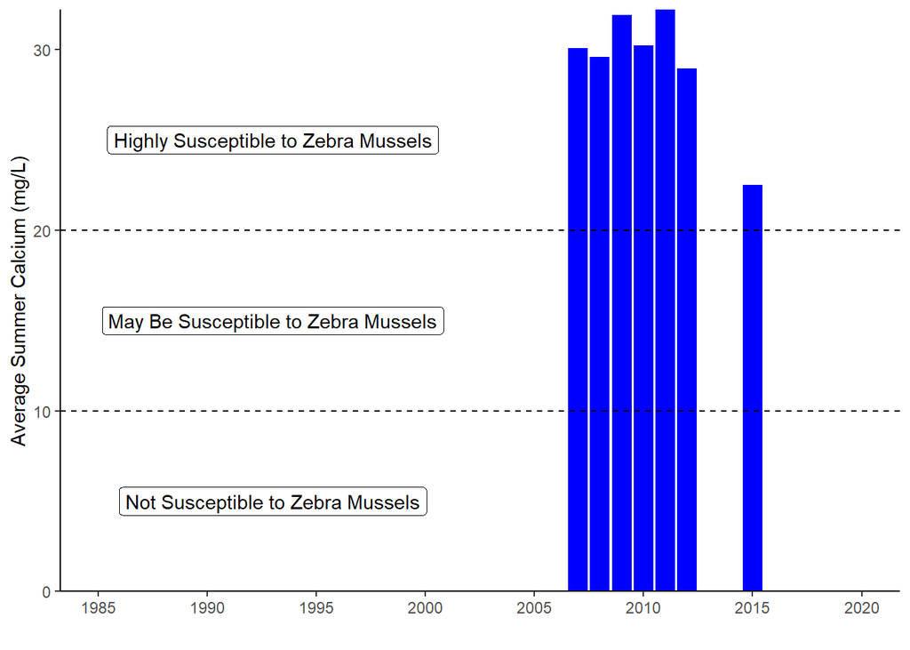

#### Chloride

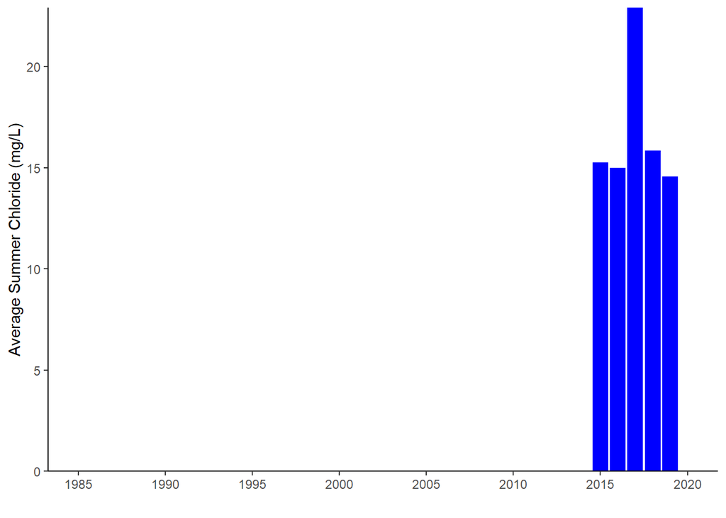

#### Color

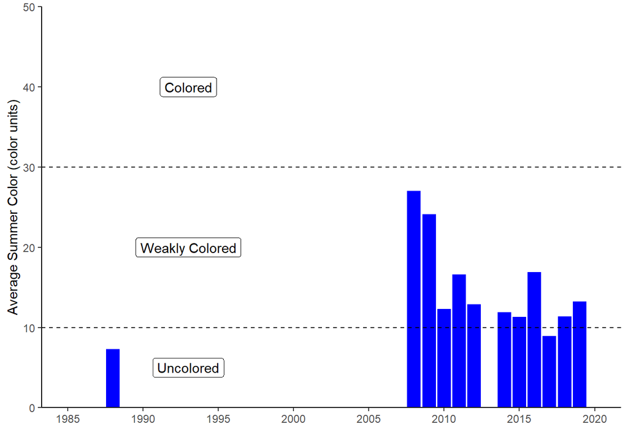

#### Surface and Deep Temperature

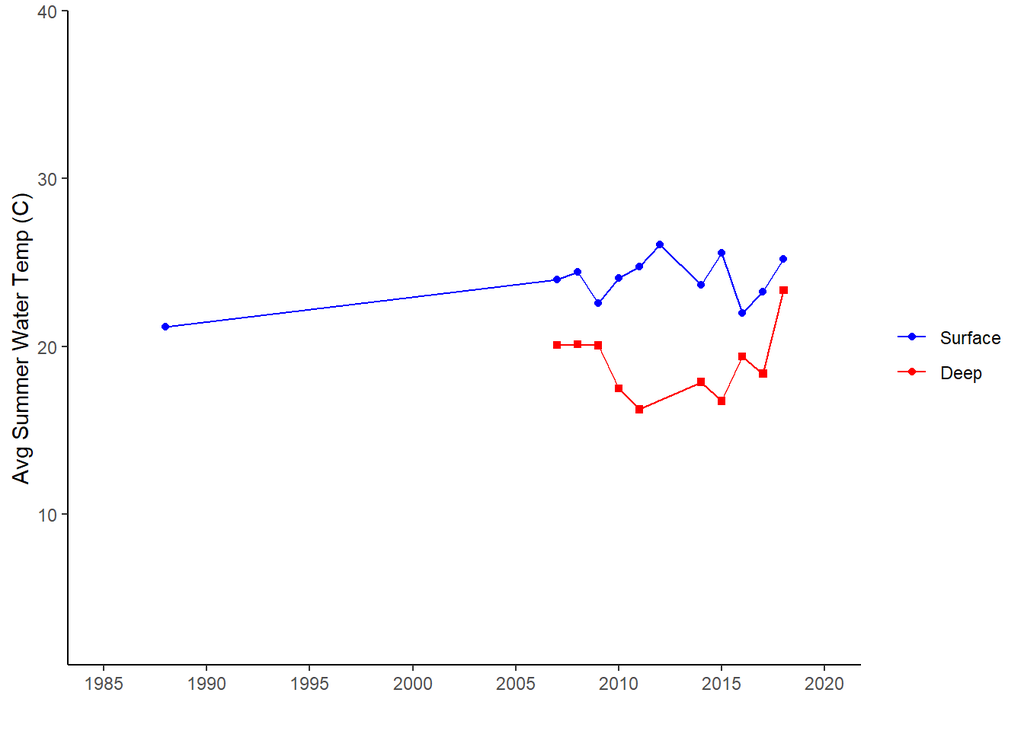

#### Lake Perception

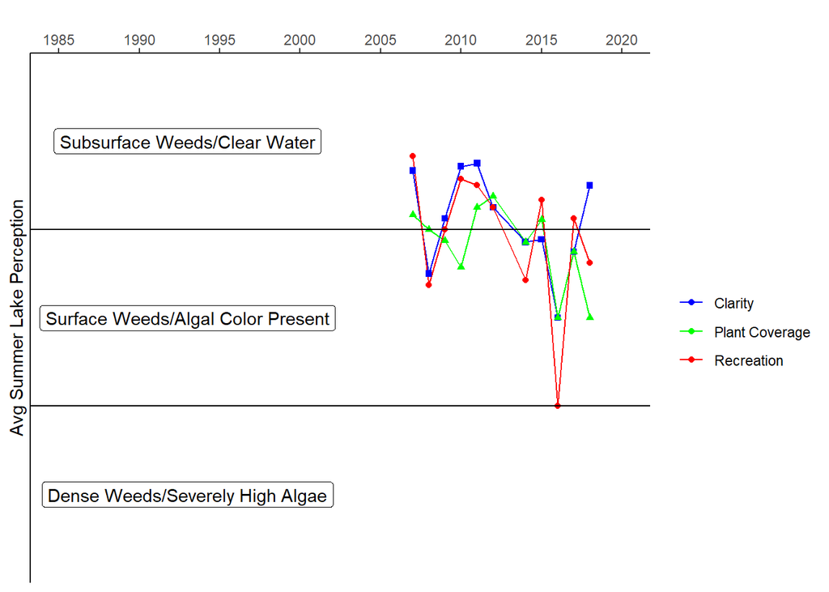